# NM2207 QUIZ

Tang Ching Xian

2023-09-18

#a. Read the contents of the dataset (only code required) dataset <- read.csv(“dataset.csv”)

#b. List all the passengers who survived in class 3 (only code required) survivors_class3 <- subset(dataset, Survived == 1 & Pclass == 3)

#c. Among those who survived in class 3, how many are female? (only code required) female_survivors_class3 <- subset(survivors_class3, Sex == “female”) num_female_survivors_class3 <- nrow(female_survivors_class3) num_female_survivors_class3

#d. What is the mean value of the age of survivors in class 3? (only code required) mean_age_survivors_class3 <- mean(survivors_class3$Age, na.rm = TRUE) mean_age_survivors_class3

#e. List the survivors in class 3 in the decreasing order of their age (only code required) survivors_class3_sorted <- survivors_class3[order(survivors_class3$Age, decreasing = TRUE), ] survivors_class3_sorted

#f. Obtain a plot of age of the survivors in class 3 versus their passenger id (only code required) plot(survivors_class3$PassengerId, survivors_class3$Age, xlab = “Passenger ID”, ylab = “Age”, type = “b”)

survivors_class3_sorted <- survivors_class3[order(survivors_class3$Age, decreasing = TRUE), ] survivors_class3_sorted

```r
# Load Tidyverse
library(tidyverse)
# Read the CSV file and assign it to the variable "titanic data"
titanic_data <- read.csv("titanic.csv")
# Overview of csv
glimpse(titanic_data)
```

```
## Rows: 891
## Columns: 12
## $ PassengerId <int> 1, 2, 3, 4, 5, 6, 7, 8, 9, 10, 11, 12, 13, 14, 15, 16, 17,…
## $ Survived    <int> 0, 1, 1, 1, 0, 0, 0, 0, 1, 1, 1, 1, 0, 0, 0, 1, 0, 1, 0, 1…
## $ Pclass      <int> 3, 1, 3, 1, 3, 3, 1, 3, 3, 2, 3, 1, 3, 3, 3, 2, 3, 2, 3, 3…
## $ Name        <chr> "Braund, Mr. Owen Harris", "Cumings, Mrs. John Bradley (Fl…
## $ Sex         <chr> "male", "female", "female", "female", "male", "male", "mal…
## $ Age         <dbl> 22, 38, 26, 35, 35, NA, 54, 2, 27, 14, 4, 58, 20, 39, 14, …
## $ SibSp       <int> 1, 1, 0, 1, 0, 0, 0, 3, 0, 1, 1, 0, 0, 1, 0, 0, 4, 0, 1, 0…
## $ Parch       <int> 0, 0, 0, 0, 0, 0, 0, 1, 2, 0, 1, 0, 0, 5, 0, 0, 1, 0, 0, 0…
## $ Ticket      <chr> "A/5 21171", "PC 17599", "STON/O2. 3101282", "113803", "37…
## $ Fare        <dbl> 7.2500, 71.2833, 7.9250, 53.1000, 8.0500, 8.4583, 51.8625,…
## $ Cabin       <chr> "", "C85", "", "C123", "", "", "E46", "", "", "", "G6", "C…
## $ Embarked    <chr> "S", "C", "S", "S", "S", "Q", "S", "S", "S", "C", "S", "S"…
```

```r
survivors_class3 <- titanic_data %>%filter(Pclass == 3) %>%filter(Survived==1)
print(survivors_class3)
```

```
##     PassengerId Survived Pclass
## 1             3        1      3
## 2             9        1      3
## 3            11        1      3
## 4            20        1      3
## 5            23        1      3
## 6            26        1      3
## 7            29        1      3
## 8            33        1      3
## 9            37        1      3
## 10           40        1      3
## 11           45        1      3
## 12           48        1      3
## 13           66        1      3
## 14           69        1      3
```

[output cut: 345 more lines]

```r
female_survivors_class3 <- survivors_class3%>%filter(Sex=="female")
number_of_female<-female_survivors_class3%>%summarise(count = n())
print(number_of_female)
```

```
##   count
## 1    72
```

```r
avg_age_in_class3 <- survivors_class3 %>%
  summarise(avg_age_in_class3 = mean(Age, na.rm = TRUE))

mean(avg_age_in_class3$avg_age_in_class3)
```

```
## [1] 20.64612
```

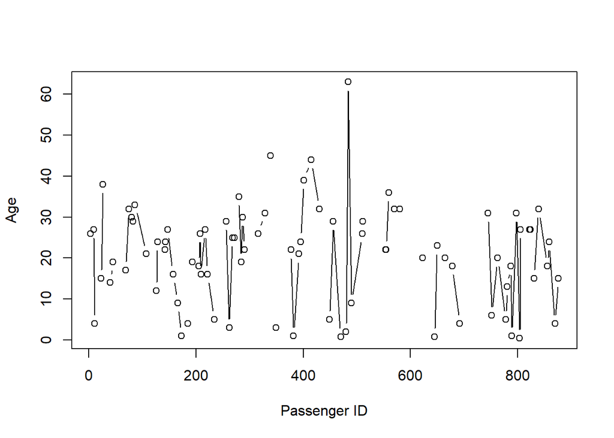

```r
plot(survivors_class3$PassengerId, survivors_class3$Age, xlab = "Passenger ID", ylab = "Age", type = "b")
```

```r
survivors_class3_sorted <- survivors_class3[order(survivors_class3$Age, decreasing = TRUE), ]
survivors_class3_sorted
```

```
##     PassengerId Survived Pclass
## 77          484        1      3
## 57          339        1      3
## 69          415        1      3
## 68          401        1      3
## 6            26        1      3
## 84          560        1      3
## 48          280        1      3
## 19           86        1      3
## 15           75        1      3
## 70          430        1      3
## 85          570        1      3
## 87          580        1      3
## 115         839        1      3
## 55          329        1      3
```

[output cut: 345 more lines]